# R Notebook

Beatriz Estrella

26/10/2020

# 1. INTRODUCTION

## 1.1. Project goal

The motivation of this project is to complete the task of the course in Data Science: Capstone from HarvardX, course PH125.9x, under the *Choose your own!* project submission.

Datasets, .R code and all relevant documentation regarding this project can be found online at github.com/beatrizeg/Wish-Units-Solds.

[output not shown]

## 1.2. Inspecting the dataset

Now we proceed to inspect the main dataset that is directly downloaded from Kaggle. Using the dim and summary functions we see:

```r
dim(main)
```

```
[1] 1460   81
```

```r
summary(main)
```

```
       Id           MSSubClass      MSZoning          LotFrontage        LotArea          Street             Alley
 Min.   :   1.0   Min.   : 20.0   Length:1460        Min.   : 21.00   Min.   :  1300   Length:1460        Length:1460
 1st Qu.: 365.8   1st Qu.: 20.0   Class :character   1st Qu.: 59.00   1st Qu.:  7554   Class :character   Class :character
 Median : 730.5   Median : 50.0   Mode  :character   Median : 69.00   Median :  9478   Mode  :character   Mode  :character
 Mean   : 730.5   Mean   : 56.9                      Mean   : 70.05   Mean   : 10517
 3rd Qu.:1095.2   3rd Qu.: 70.0                      3rd Qu.: 80.00   3rd Qu.: 11602
 Max.   :1460.0   Max.   :190.0                      Max.   :313.00   Max.   :215245
                                                     NA's   :259
   LotShape         LandContour         Utilities          LotConfig          LandSlope         Neighborhood
 Length:1460        Length:1460        Length:1460        Length:1460        Length:1460        Length:1460
 Class :character   Class :character   Class :character   Class :character   Class :character   Class :character
 Mode  :character   Mode  :character   Mode  :character   Mode  :character   Mode  :character   Mode  :character




  Condition1         Condition2          BldgType          HouseStyle         OverallQual      OverallCond      YearBuilt
 Length:1460        Length:1460        Length:1460        Length:1460        Min.   : 1.000   Min.   :1.000   Min.   :1872
 Class :character   Class :character   Class :character   Class :character   1st Qu.: 5.000   1st Qu.:5.000   1st Qu.:1954
 Mode  :character   Mode  :character   Mode  :character   Mode  :character   Median : 6.000   Median :5.000   Median :1973
                                                                             Mean   : 6.099   Mean   :5.575   Mean   :1971
                                                                             3rd Qu.: 7.000   3rd Qu.:6.000   3rd Qu.:2000
                                                                             Max.   :10.000   Max.   :9.000   Max.   :2010

  YearRemodAdd   RoofStyle           RoofMatl         Exterior1st        Exterior2nd         MasVnrType          MasVnrArea
 Min.   :1950   Length:1460        Length:1460        Length:1460        Length:1460        Length:1460        Min.   :   0.0
 1st Qu.:1967   Class :character   Class :character   Class :character   Class :character   Class :character   1st Qu.:   0.0
 Median :1994   Mode  :character   Mode  :character   Mode  :character   Mode  :character   Mode  :character   Median :   0.0
 Mean   :1985                                                                                                  Mean   : 103.7
 3rd Qu.:2004                                                                                                  3rd Qu.: 166.0
 Max.   :2010                                                                                                  Max.   :1600.0
                                                                                                               NA's   :8
  ExterQual          ExterCond          Foundation          BsmtQual           BsmtCond         BsmtExposure
 Length:1460        Length:1460        Length:1460        Length:1460        Length:1460        Length:1460
 Class :character   Class :character   Class :character   Class :character   Class :character   Class :character
 Mode  :character   Mode  :character   Mode  :character   Mode  :character   Mode  :character   Mode  :character




```

[output cut: 40 more lines]

```
 EnclosedPorch      3SsnPorch       ScreenPorch        PoolArea          PoolQC             Fence           MiscFeature
 Min.   :  0.00   Min.   :  0.00   Min.   :  0.00   Min.   :  0.000   Length:1460        Length:1460        Length:1460
 1st Qu.:  0.00   1st Qu.:  0.00   1st Qu.:  0.00   1st Qu.:  0.000   Class :character   Class :character   Class :character
 Median :  0.00   Median :  0.00   Median :  0.00   Median :  0.000   Mode  :character   Mode  :character   Mode  :character
 Mean   : 21.95   Mean   :  3.41   Mean   : 15.06   Mean   :  2.759
 3rd Qu.:  0.00   3rd Qu.:  0.00   3rd Qu.:  0.00   3rd Qu.:  0.000
 Max.   :552.00   Max.   :508.00   Max.   :480.00   Max.   :738.000

    MiscVal             MoSold           YrSold       SaleType         SaleCondition        SalePrice
 Min.   :    0.00   Min.   : 1.000   Min.   :2006   Length:1460        Length:1460        Min.   : 34900
 1st Qu.:    0.00   1st Qu.: 5.000   1st Qu.:2007   Class :character   Class :character   1st Qu.:129975
 Median :    0.00   Median : 6.000   Median :2008   Mode  :character   Mode  :character   Median :163000
 Mean   :   43.49   Mean   : 6.322   Mean   :2008                                         Mean   :180921
 3rd Qu.:    0.00   3rd Qu.: 8.000   3rd Qu.:2009                                         3rd Qu.:214000
 Max.   :15500.00   Max.   :12.000   Max.   :2010                                         Max.   :755000
```

The dataset consists of 1460 rows and 81 columns. We see that we have a mix of character and numeric values. 81 columns is quite a lot of columns as each of them would represent a feature and probably not all of them help predict the sale price of a house. We will try to reduce the number of columns early in the project to be able to work better with the data.

### 1.2.1. Dealing with NAs

First things first, let’s check the NAs. To check which columns gives us NAs we use.

```r
nas <- apply(main, 2, function(x) any(is.na(x)))
knitr::kable(nas[which(nas)], caption = "Check columns with NAs")
```

Check columns with NAs

|  | x |
| --- | --- |
| LotFrontage | TRUE |
| Alley | TRUE |
| MasVnrType | TRUE |
| MasVnrArea | TRUE |
| BsmtQual | TRUE |
| BsmtCond | TRUE |
| BsmtExposure | TRUE |
| BsmtFinType1 | TRUE |
| BsmtFinType2 | TRUE |
| Electrical | TRUE |
| FireplaceQu | TRUE |
| GarageType | TRUE |
| GarageYrBlt | TRUE |
| GarageFinish | TRUE |
| GarageQual | TRUE |
| GarageCond | TRUE |
| PoolQC | TRUE |
| Fence | TRUE |
| MiscFeature | TRUE |

We see that from a total of 81 columns, 19 of them contain NAs. If we check the data description file, let’s describe each of these columns.

· LotFrontage: This is a numeric value that represents linear feet of street connected to property -> we have a total of *259/1460=17.7%* which can be acceptable to keep this data but NAs will be substituted by 0 so that we can perform calculations with this data. · Alley: This is a character value in which NA represents that there is no alley access. · MasVnrType: This is a character value in which NA is a *not applicable* value. Let’s check how many of them we have.

```r
sum(is.na(main$MasVnrType))
```

```
[1] 8
```

We only have 8 values with NA so is does not seem like a reason to disregard the column data. · MasVnrArea: same as before, in this case it is a numeric value with same number of NAs. · BsmtQual: it evaluates the height of the basement in a categorical value and we have 37 NAs. · BsmtCond: evaluates the general condition of the basement and gives the same result as previous line. · BsmtExposure, BsmtFinType1 and BsmtFinType2: gives NAs as well in case of no basement. · Electrical: categorical feature with only 1 NA. · FireplaceQu: it is a categorical value that provides the fireplace quality. NA represents no fireplace and in this case we get 690 values. · Garage: all garage related features. They show different aspects of garages and NAs represent no garage. · PoolQC: it shows pool quality and NA represents No Pool. · Fence: represents fence quality and NA respresents No Fence. · MiscFeature: it is a categorical miscellaneous feature such as elevator, tennis court, etc. NA represents None.

```r
main <- main %>% mutate(LotFrontage=ifelse(is.na(LotFrontage),0,LotFrontage),
                        Alley=ifelse(is.na(Alley),'None',Alley),
                        MasVnrType=ifelse(is.na(MasVnrType),'None',MasVnrType),
                        MasVnrArea=ifelse(is.na(MasVnrArea),0,MasVnrArea),
                        BsmtQual=ifelse(is.na(BsmtQual),'None',BsmtQual),
                        BsmtCond=ifelse(is.na(BsmtCond),'None',BsmtCond),
                        BsmtExposure=ifelse(is.na(BsmtExposure),'None',BsmtExposure),
                        BsmtFinType1=ifelse(is.na(BsmtFinType1),'None',BsmtFinType1),
                        BsmtFinType2=ifelse(is.na(BsmtFinType2),'None',BsmtFinType2),
                        FireplaceQu=ifelse(is.na(FireplaceQu),'None',FireplaceQu),
                        GarageType=ifelse(is.na(GarageType),'None',GarageType),
                        GarageYrBlt=ifelse(is.na(GarageYrBlt),'None',GarageYrBlt),
                        GarageFinish=ifelse(is.na(GarageFinish),'None',GarageFinish),
                        GarageQual=ifelse(is.na(GarageQual),'None',GarageQual),
                        GarageCond=ifelse(is.na(GarageCond),'None',GarageCond),
                        PoolQC=ifelse(is.na(PoolQC),'None',PoolQC),
                        Fence=ifelse(is.na(Fence),'None',Fence),
                        MiscFeature=ifelse(is.na(MiscFeature),'None',MiscFeature))
```

### 1.2.2. Dealing with factor variables

```r
main[sapply(main, is.character)] <- lapply(main[sapply(main, is.character)],
                                                           as.factor)
```

Lastly, it is important to note that the Id column provides a unique Id to each house.

# 2. METHOD AND ANALYSIS

## 2.1. Exploration of the dataset

Now we proceed to inspect the different features/variables in the dataset, taking into account that the value we want to be able to predict is *SalePrice*.

### 2.1.1. Checking features variability and adjusting

Because checking 79 features one by one to analyze variability can take too long, let’s start with analyzing those predictors that maintain close to same value across all the same to check if we want to disregard them.

```r
no_var <- nearZeroVar(main, saveMetrics = TRUE)
knitr::kable(no_var[no_var[,"zeroVar"] + no_var[,"nzv"] > 0, ],
             caption = "Predictors with near zero variability")
```

Predictors with near zero variability

|  | freqRatio | percentUnique | zeroVar | nzv |
| --- | --- | --- | --- | --- |
| Street | 242.33333 | 0.1369863 | FALSE | TRUE |
| Alley | 27.38000 | 0.2054795 | FALSE | TRUE |
| LandContour | 20.80952 | 0.2739726 | FALSE | TRUE |
| Utilities | 1459.00000 | 0.1369863 | FALSE | TRUE |
| LandSlope | 21.26154 | 0.2054795 | FALSE | TRUE |
| Condition2 | 240.83333 | 0.5479452 | FALSE | TRUE |
| RoofMatl | 130.36364 | 0.5479452 | FALSE | TRUE |
| BsmtCond | 20.16923 | 0.3424658 | FALSE | TRUE |
| BsmtFinType2 | 23.25926 | 0.4794521 | FALSE | TRUE |
| BsmtFinSF2 | 258.60000 | 9.8630137 | FALSE | TRUE |
| Heating | 79.33333 | 0.4109589 | FALSE | TRUE |
| LowQualFinSF | 478.00000 | 1.6438356 | FALSE | TRUE |
| KitchenAbvGr | 21.41538 | 0.2739726 | FALSE | TRUE |
| Functional | 40.00000 | 0.4794521 | FALSE | TRUE |
| EnclosedPorch | 83.46667 | 8.2191781 | FALSE | TRUE |
| 3SsnPorch | 478.66667 | 1.3698630 | FALSE | TRUE |
| ScreenPorch | 224.00000 | 5.2054795 | FALSE | TRUE |
| PoolArea | 1453.00000 | 0.5479452 | FALSE | TRUE |
| PoolQC | 484.33333 | 0.2739726 | FALSE | TRUE |
| MiscFeature | 28.69388 | 0.3424658 | FALSE | TRUE |
| MiscVal | 128.00000 | 1.4383562 | FALSE | TRUE |

We do not get any feature with Zero Variance but we do get quite an important number of features with NearZeroVariance. Among all of them, we will eliminate from our model *Street*, *Alley*, *Condition2*, *RoofMatl*,*BsmtFinType2* and *BsmtFinSF2*, *LowQualFinSF* and *PoolQC*, as these are the variables with less variability and per the data description, we understand they have the less impact in a house sale price.

Now, from a start of 79 features, we continue with 71. 71 variables is still quite a lot.

## 2.2. Studying correlation between variables

Because we want to further study and understand if all 71 features should be kept in the model, we will now proceed with studying correlation among the different variables. For those that are high correlated to each other, only one of them should be kept in model disregarding the correlated ones.

As we have both numeric and string values, we need to study correlation separately. We will start first with the numeric values.

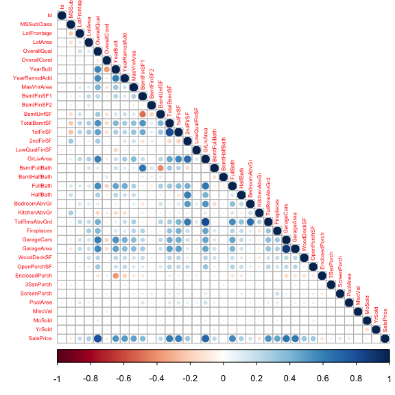

```r
main_m.cor <- main_m %>%
  dplyr::select_if(is.numeric) %>%
  cor(.)
corrplot(main_m.cor, type="lower", tl.cex = 0.5)
```

When looking at the results we can see different interesting things.

What we want to do here is check the pair of variables that have a high correlation and remove one of them. For this, we can use the findCorrelation function from caret library. We see that the function recommends disregarding variable GrLivArea, which is highly correlated to TotRmsAbvGrd, also 1stFlrSF, which is highly correlated to TotalBsmtST and GarageCars, highly correlated to GarageArea.

```r
highlyCorrelated <- caret::findCorrelation(main_m.cor, cutoff=0.7, names = TRUE)
```

We will remove those 3 variables from the ongoing model. Also, worth mentioning that of course, our SalePrice variable cannot be remove as this is the variable we are trying to predict.

To study correlation between non numerical variables, we will perform a Chi-squared test of independence, looking at the p-values. We can say that two different variables are independent if the probability distribution of one is not affected by the presence of the other.

```r
main_m.chisq <- main_m %>%
  dplyr::select_if(function(col) is.character(col) |
                     is.factor(col) | is.logical(col) |
                     all(col == .$SalePrice)) %>% dplyr::select(-.$Id)

columns <- 1:ncol(main_m.chisq)
vars <- names(main_m.chisq)[columns]
out <-  apply( combn(columns,2),2,function(x){
  chisq.test(table(main_m.chisq[,x[1]],main_m.chisq[,x[2]]),correct=F)$p.value
})

out <- cbind(as.data.frame(t(combn(vars,2))),out)
out_dep <- out %>% filter(V2=="SalePrice") %>% filter(out<0.05) %>% arrange(out)
knitr::kable(out_dep, caption = "Dependent categorical variables from SalePrice")
```

Dependent categorical variables from SalePrice

| V1 | V2 | out |
| --- | --- | --- |
| ExterQual | SalePrice | 0.0000000 |
| KitchenQual | SalePrice | 0.0000000 |
| BsmtQual | SalePrice | 0.0000000 |
| Heating | SalePrice | 0.0000000 |
| BsmtCond | SalePrice | 0.0000000 |
| BsmtExposure | SalePrice | 0.0000000 |
| SaleType | SalePrice | 0.0000000 |
| SaleCondition | SalePrice | 0.0000000 |
| ExterCond | SalePrice | 0.0000000 |
| LotShape | SalePrice | 0.0000000 |
| MSZoning | SalePrice | 0.0000000 |
| GarageFinish | SalePrice | 0.0000000 |
| Neighborhood | SalePrice | 0.0000000 |
| FireplaceQu | SalePrice | 0.0000000 |
| MasVnrType | SalePrice | 0.0000016 |
| Foundation | SalePrice | 0.0000097 |
| CentralAir | SalePrice | 0.0000123 |
| LotConfig | SalePrice | 0.0458062 |

```r
out_ind <- out %>% filter(V2=="SalePrice") %>% filter(out>=0.05) %>% arrange(out)
knitr::kable(out_ind, caption = "Independent categorical variables from SalePrice")
```

Independent categorical variables from SalePrice

| V1 | V2 | out |
| --- | --- | --- |
| GarageQual | SalePrice | 0.0501487 |
| Electrical | SalePrice | 0.0556880 |
| GarageType | SalePrice | 0.0647807 |
| LandContour | SalePrice | 0.0867465 |
| LandSlope | SalePrice | 0.1050864 |
| BsmtFinType1 | SalePrice | 0.2129277 |
| HouseStyle | SalePrice | 0.6482615 |
| Exterior2nd | SalePrice | 0.8469190 |
| BsmtFinType2 | SalePrice | 0.9480709 |
| PavedDrive | SalePrice | 0.9912800 |
| HeatingQC | SalePrice | 0.9995947 |
| Exterior1st | SalePrice | 0.9999839 |
| BldgType | SalePrice | 0.9999861 |
| PoolQC | SalePrice | 1.0000000 |
| GarageCond | SalePrice | 1.0000000 |
| Fence | SalePrice | 1.0000000 |
| MiscFeature | SalePrice | 1.0000000 |
| Utilities | SalePrice | 1.0000000 |
| Condition1 | SalePrice | 1.0000000 |
| RoofStyle | SalePrice | 1.0000000 |
| RoofMatl | SalePrice | 1.0000000 |
| Functional | SalePrice | 1.0000000 |
| GarageYrBlt | SalePrice | 1.0000000 |

We will be able to check on this when we study the variable importance of the machine learning algorithms.

## 2.4. Creation of train and test set

We split our data into a train set where we run the algorithms, and a test set to test the results and see how good our algorithm did. Test set usually consists of 10%-20% of the data. In our case, test set will have 15% of the data and train set 85%. As we do not have too much data, we do not want to compromise test set to have very few rows, or train set to not be big enough to produce good models.

Our train set consists of 1138 rows and test set of 203 rows.

```r
set.seed(1, sample.kind = "Rounding")
test_index <- createDataPartition(main_m$SalePrice, times=1, p=0.15, list=FALSE)
train_set <- main_m[-test_index,] %>% dplyr::select(-Id)
test_set <- main_m[test_index,] %>% dplyr::select(-Id)
```

## 2.5. Method

The method will be to train different Machine Learning algorithms, that are included in `caret` package. We will train the models using only the train_set, while repeated cross-validation or simple cross-validation will be used to optimize the hyperparameters of each model. Once the model is optimized using only the train_set, results will be tested in test_set.

The methods to use are those appropriate to study a regression problem such as this one. Thus, we will be using *Linear Regression Model*, *Neural Network Models*, *Random Forest*, *SVM* or *Lasso Regression*.

As well, `h2o` package will be used at the end, to check which is the best performer model and compare results.

# 3. RESULTS

## 3.1. GAM Loess